# ‘Unstacking’ Bars

lindbrook

2016-09-25

## Overview

In his map of the 1854 cholera outbreak in London, John Snow used stacks of bars to represent the number of fatalities at an address: for example, a location with one fatality is represented by a single, horizontal bar; a location with five is represented by five horizontally stacked bars:[^1]

[figure not shown]

In 1992, Rusty Dodson and Waldo Tobler digitized the map. Each bar and water pump was given a unique x-y coordinate. Each road was translated into a set of straight line segments, defined by their endpoints. While the original data are no longer available,[^2] they are included in Michael Friendly’s *HistData* R package. The data are plotted below:

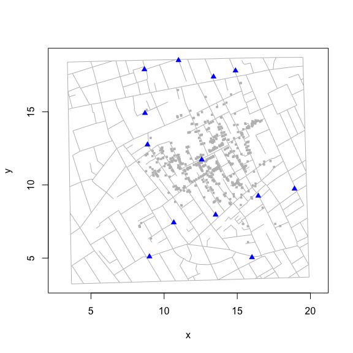

Despite their appeal, I would argue that stacks are visually and computationally problematic. The reason? Not all bars are created equal. Even though they are identical in terms of their appearance and the only thing that seems to distinguish them is their position on the map, bars actually play two different roles. Sometimes a bar represent the location of a fatality, sometimes it doesn’t. Standalone bars (i.e., a stack with a one bar or an addresses with one fatality), or of the bar at the base of a stack do. Bars above the base case do not: their only purpose is to create the visual stacking effect.

While this duality is not inherently problematic, it becomes problematic in a map. Because a map is a visual device that illustrates spatial relationships, it’s natural to assume that the positions of all elements (e.g., bars) represent actual physical locations. So when we violate this principle, we undermine our visual interpretation of the map and handicap our attempt to analyze the data in the map. This is particularly true when 44% (257/578) of bars in Snow’s map fall into this geographically uninformative category.

To address these problems, I “unstack” Dodson and Tobler’s data. I do so in two different data sets. The first, *fatalities.unstacked*, “unstacks” the data so that all cases in a stack (at the same “address”) are given the same x-y coordinate. The second, *unstacked.address*, “unstacks” the data by changing the unit of observation from the case to the stack (or “address”). Each “address” is a single observation with a single x-y coordinate, and the number of cases at that location becomes an attribute of the “address”.

## Data details

To illustrate the differences between these datasets, consider how they treat the biggest outlier on Snow’s map: the 18 cases at 38 Broad Street. The code below below compares Dodson and Tobler’s data to *fatalities.unstacked*

```r
## The 18 cases at 38 Broad Street ##

broad38 <- c(239, 12, 310, 398, 562, 397, 421, 190, 290, 61, 174, 547, 523, 521,
             138, 59, 340, 508)

# With fatalities, all members of the stack have different coordinates

fatalities[fatalities$case %in% broad38, ]
```

```
#>     case        x        y
#> 12    12 12.34107 11.48214
#> 59    59 12.58271 11.01057
#> 61    61 12.47289 11.21463
#> 138  138 12.56326 11.04593
#> 174  174 12.48731 11.17735
#> 190  190 12.44094 11.28124
#> 239  239 12.31552 11.51159
#> 290  290 12.45943 11.24890
#> 310  310 12.35546 11.44285
#> 340  340 12.59532 10.98533
#> 397  397 12.40901 11.34986
#> 398  398 12.36903 11.41560
#> 421  421 12.42551 11.31754
#> 508  508 12.61480 10.95197
#> 521  521 12.54972 11.07519
#> 523  523 12.53218 11.10452
#> 547  547 12.51176 11.14190
#> 562  562 12.39045 11.37820
```

```r
# With fatalities.unstacked, all members of the stack have identical coordinates

fatalities.unstacked[fatalities.unstacked$case %in% broad38, ]
```

```
#>     case        x        y
#> 12    12 12.31552 11.51159
#> 59    59 12.31552 11.51159
#> 61    61 12.31552 11.51159
#> 138  138 12.31552 11.51159
#> 174  174 12.31552 11.51159
#> 190  190 12.31552 11.51159
#> 239  239 12.31552 11.51159
#> 290  290 12.31552 11.51159
#> 310  310 12.31552 11.51159
#> 340  340 12.31552 11.51159
#> 397  397 12.31552 11.51159
#> 398  398 12.31552 11.51159
#> 421  421 12.31552 11.51159
#> 508  508 12.31552 11.51159
#> 521  521 12.31552 11.51159
#> 523  523 12.31552 11.51159
#> 547  547 12.31552 11.51159
#> 562  562 12.31552 11.51159
```

The code below shows the structure of *unstacked.address*. Here, the 18 cases at 38 Broad Street are represented by a single observation, case 239, which serves as the nominal representative for the “address”:

```r
# The 18 cases at 38 Broad street are nominally represented by case 239

fatalities.address[136:140, ]
```

```
#>     anchor.case         x        y case.count
#> 236         237 15.775540 13.98787          2
#> 238         238 12.900190 10.33882          1
#> 239         239 12.315520 11.51159         18
#> 257         240  9.794394 11.77236          1
#> 258         242 12.677590 12.05460          1
```

## Virtues of “unstacking”

To illustrate the problems with “stacked” data and the virtues of “unstacked” data, consider two examples.

### Kernel density contours

The first example applies applies bivariate kernel density contours, of varying bandwidth, to “stacked” and “unstacked” data. The plots illustrate the spatial distribution or topography of fatalities, and provides a way to estimate the epicenter, if not the source, of the outbreak.

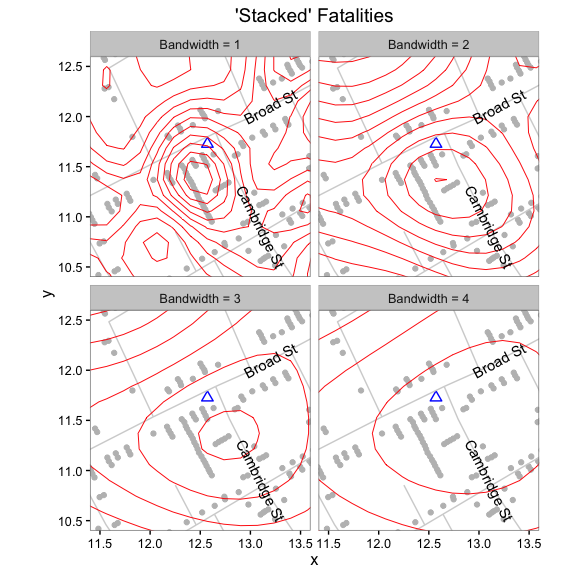

With *fatalities.unstacked*, the contours and epicenter are located further north, nearer to both the pump and Broad Street:

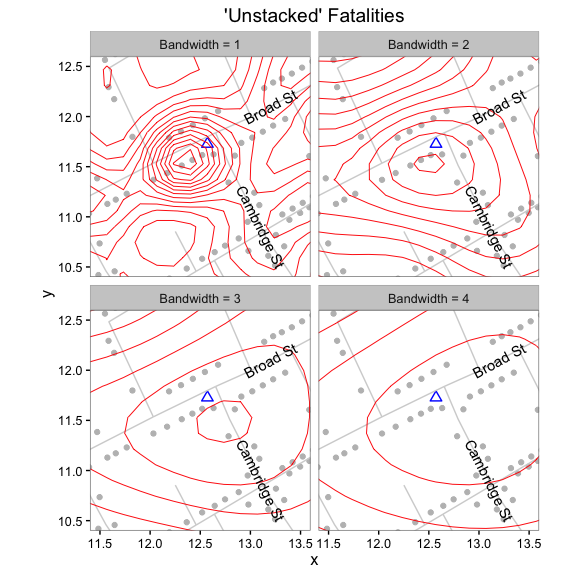

### An alternative approach to “stacks”

The second example uses *unstacked.address* to create an alternative to “stacked” bars based on proportionately sized points. Each address is represented by a square whose size is determined by the number of fatalities and whose location is represented by a point at its center.[^3]

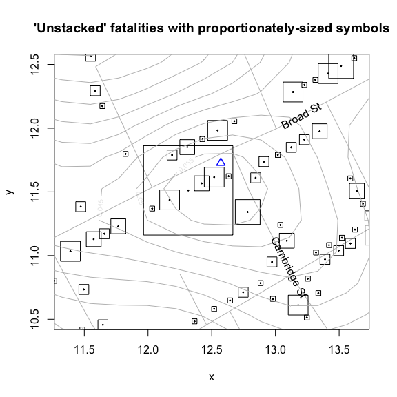

## “Unstacking” via classification

This section discusses the specifics of how I “unstacked” the data. The main roadblock that makes “unstacking” difficult is that there is no notion of an “address”. Bars are merely points and streets are merely line segments.[^4] Nothing links the points to segments. And nothing connects one bar in a stack to another. All elements exist independently of one another. The only reason why the map “works” is that the fatalities and roads data have overlapping x-y coordinates.

Therefore, to “unstack” the data , we need match each bar to a specific road (segment) and to match each bar to a specific stack. To accomplish these tasks, I employ two different classifications methods.

### Orthogonal projection

The first method works by orthogonal projection. For each bar, the algorithm draws a series of lines that pass through that bar and that are orthogonal to each *nearby* road segment.[^5] If a projected line intersects or bisects a road segment, it becomes a candidate for the bar’s home segment. If there’s more than one candidate, the algorithm chooses the segment that is “closest” to the bar: this will be the segment with the shortest orthogonal projector.

To illustrate, consider the stylized example in the figure below. For case 12, there are three possible “home” road segments: the solid blue, red and green segments.

We consider them because at least one of their endpoints fall within 50 meters, or on the map’s nominal scale a distance of 0.5, of case 12’s position. Of the three, only *red* and *green* are viewed as candidates. The problem with *blue* is that the orthogonal projection from case 12 (the blue arrow) does not intersect the solid blue segment. Of the two candidates, *red* is chosen because it is closer to case 12 than *green*: the red arrow is shorter than the green one.

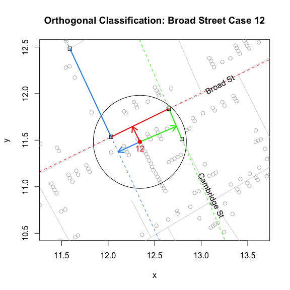

This procedure correctly classifies 515 of 578 of the cases, an error rate of 10.9%. Errors occur due to ambiguities surrounding a case’s “home” segment. Unlike Snow’s map where a bar’s “horizontal” orientation indicates its “home” segment, Dodson and Tobler only record a case’s x-y coordinates. This can lead to problems at street intersections, where a point may be closer to the “wrong” segment, and at addresses with many cases.[^6] The problem with multiple cases is that stacking pushes cases away from the “home” segment. Consider the figure below. Even though visual inspection (the alignment of the stack) should lead us to choose *black*, the algorithm chooses *red*. The reason for the error is that stacking pushes the case so far from *black* that it lies beyond consideration.[^7] With stacks, this kind of misclassification is always a potential threat.

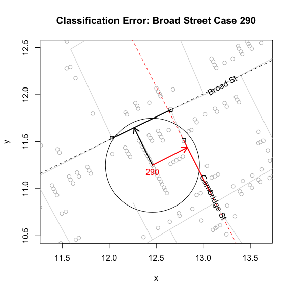

All errors were corrected by manually recoding cases.

### Cluster analysis

To match a bar to a stack, I use hierarchical cluster analysis.[^8] To make this task easier, instead of its x-y coordinates I use a bar’s orthogonal coordinates. That is, I use the point where the the orthogonal projection from the bar intersects the road segment. Doing so reduces the dimensionality of the problem: the algorithm only needs to compare positions of points along a line.

The figure below illustrates this approach. Using a case’s x-y coordinates, the graph plots the case’s numeric ID and draws the corresponding orthogonal projector to Broad Street. Matching a bar to a stack, which is equivalent to identifying a stack, means identifying distinct clusters of points along the road segment. For the case at hand, visual inspection leads us to expect that we should find 8 different clusters along this segment of Broad Street (4 on the north side, 4 on the south side).[^9]

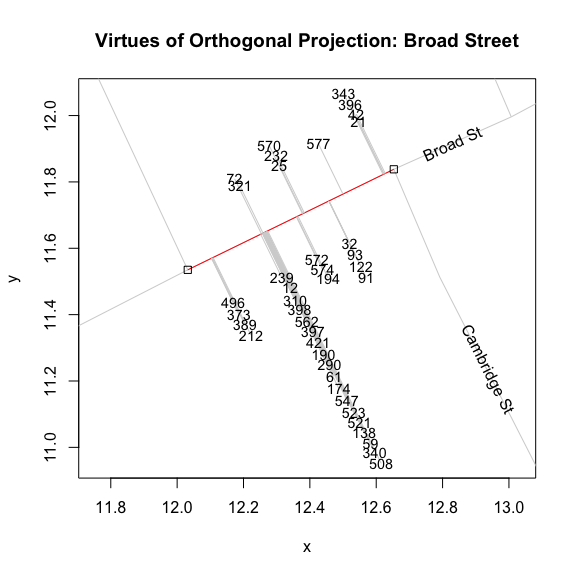

This can be confirmed by examining Snow’s map[^10]:

[figure not shown]

The fly in the ointment is that addresses directly opposite one another will have “identical” orthogonal points and will appear to belong to the same “address”. A simple solution to distinguish clusters on one side of the street from those on the other is to compute the *sign* of the arithmetic difference between a case’s x-y coordinate and its orthogonal coordinate. For example, consider cases 321 and 239. They lie on opposite sides of Broad Street. In the figure below, 321’s coordinates are shown in blue while 239’s are shown in red. When we take the signs of the differences, we get (-, +) for 321 and (+, -) for 239. This distinguishes cases on the north side from those on the south side.

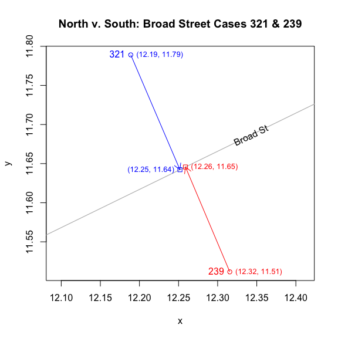

With this information, I can use cluster analysis to identify stacks, or “addresses”, on each side of a candidate road segment. Since we expect the distances between cases in a stack or “address” to be small, I use an arbitrarily low but reasonable cutoff “height” of 0.05. The two dendrograms below represent the North and South sides of Broad Street. We can see that this procedure correctly classifies the 8 different groups or stacks that can be seen in the figure above and that can be verified by looking at Snow’s map.

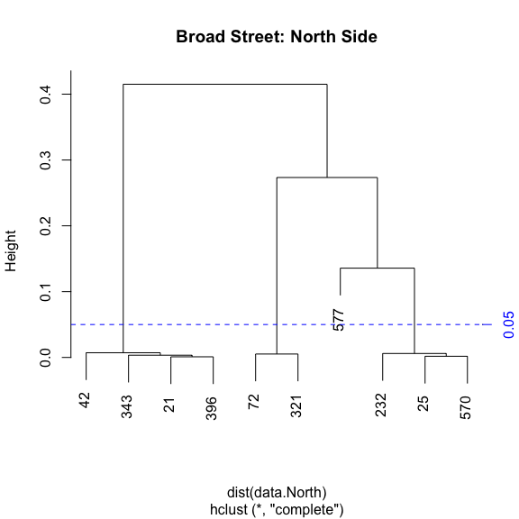

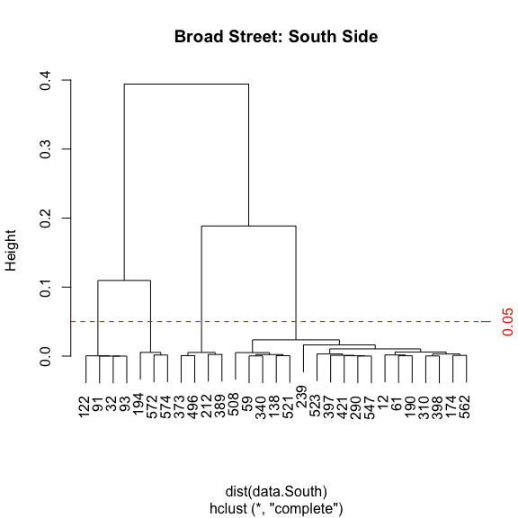